# Redblulff

Rosemary Hartman

11/4/2019

# Introduction

This is my graph of the Red Bluff rotory screw trap data. The data is collected by USFWS’s fish traps just below Shasta Dam. The passage of juvenile fish moving down the Sacramento River gives you an estimate of production for the upper part of the river. I made a graph of the Winter-Run Juvenile chinook passage estimate over the past 15 years to see how passage has changed over time.

# Analysis

I downloaded the data from the USFWS [website](http://www.cbr.washington.edu/sacramento/data/php/rpt/redbluff_daily.php?outputFormat=csv&year=2019&biweekly=other&wtemp=default), but it came in multiple bi-weekly files, so the first step was stitching it together into one file.

This is what the dataset looks like

```r
head(redbluff)
```

```
##         Date                         runname Dailypassage Month
## 1 2004-06-28 Winter.Chinook.Passage.Estimate            0     6
## 2 2004-06-29 Winter.Chinook.Passage.Estimate            0     6
## 3 2004-06-30 Winter.Chinook.Passage.Estimate            0     6
## 4 2004-07-01 Winter.Chinook.Passage.Estimate            0     7
## 5 2004-07-02 Winter.Chinook.Passage.Estimate            0     7
## 6 2004-07-03 Winter.Chinook.Passage.Estimate            0     7
```

Now I need to calculate the mean passage for the winter-run Chinook during the months of December, January, and FEbruary. So first I subset the data so that it just included winter-run chinook for the winter months (December, January, February). I lumped data from December of one year with January and February for the next year before taking the daily mean.

```r
#subset just the winter months
redbluff$Month = month(redbluff$Date)
RedWinter = filter(redbluff, Month == 12 | Month == 1 | Month == 2)

#lump december with jan and feb
RedWinter$Year2 = year(RedWinter$Date)
RedWinter$Year2[which(RedWinter$Month== 1 | RedWinter$Month == 2)] = year(RedWinter$Date[which(RedWinter$Month== 1 | RedWinter$Month == 2)])-1

#Filter out 2018 and 2019
RedWinter = filter(RedWinter, Year2 < 2018)

#calculate mean passage
meanwinter = group_by(RedWinter, Year2, runname) %>% summarize(meandaily = mean(Dailypassage, na.rm = T))
```

# REsults

Now we can make a graph of the results. I also included a red dotted line with the grand mean across all years of the data.

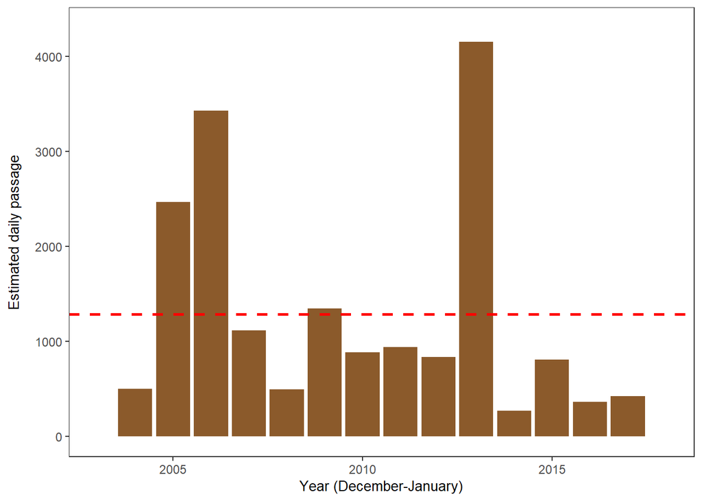

|  | Year2 | runname | meandaily |
| --- | --- | --- | --- |
| 1 | 2004 | Fall.Chinook.Passage.Estimate | 71277.4230769231 |
| 2 | 2004 | Late.Fall.Chinook.Passage.Estimate | 6465.16666666667 |
| 3 | 2004 | Spring.Chinook.Passage.Estimate | 1087.38461538462 |
| 4 | 2004 | Winter.Chinook.Passage.Estimate | 500.782051282051 |
| 5 | 2005 | Fall.Chinook.Passage.Estimate | 94201.78 |
| 6 | 2005 | Late.Fall.Chinook.Passage.Estimate | 109.08 |
| 7 | 2005 | Spring.Chinook.Passage.Estimate | 3879.12 |
| 8 | 2005 | Winter.Chinook.Passage.Estimate | 2465.44 |
| 9 | 2006 | Fall.Chinook.Passage.Estimate | 106269.012195122 |
| 10 | 2006 | Late.Fall.Chinook.Passage.Estimate | 151.926829268293 |

[output cut: 46 more lines]